# Tugas Pertemuan 2 - Pemulusan Data Harga Cabai Merah

Putra Ramadhana

## Deskripsi Data

Data yang digunakan adalah data harga harian **Cabai Merah** sebanyak 100 periode (16 Desember 2022 – 4 Mei 2023). Data ini merupakan data deret waktu tanpa pola musiman yang jelas (periode pengamatan kurang dari satu tahun), sehingga metode pemulusan yang diterapkan pada tugas ini adalah **Single Moving Average (SMA)**, **Double Moving Average (DMA)**, **Single Exponential Smoothing (SES)**, dan **Double Exponential Smoothing (DES)**. Metode Holt-Winters (musiman) tidak digunakan karena data tidak menunjukkan pola musiman/berulang yang cukup panjang untuk diidentifikasi.

## Library/Packages

```r
library(forecast)
library(TTR)
```

```r
library(ggplot2)
```

## Impor Data

```r
dataCabai <- read.csv2("C:\\Users\\Roshan\\OneDrive\\Documents\\Kuliah\\MPDW\\MPDW Cabai merah (100 Periode).csv")
dataCabai$Harga <- as.numeric(dataCabai$Harga)
dataCabai$Periode <- 1:nrow(dataCabai)

head(dataCabai)
```

```
##     Komoditas    Tanggal Harga Periode
## 1 Cabai Merah 16/12/2022 38.35       1
## 2 Cabai Merah 19/12/2022 38.80       2
## 3 Cabai Merah 20/12/2022 39.35       3
## 4 Cabai Merah 21/12/2022 39.40       4
## 5 Cabai Merah 22/12/2022 39.50       5
## 6 Cabai Merah 23/12/2022 39.55       6
```

```r
str(dataCabai)
```

```
## 'data.frame':    100 obs. of  4 variables:
##  $ Komoditas: chr  "Cabai Merah" "Cabai Merah" "Cabai Merah" "Cabai Merah" ...
##  $ Tanggal  : chr  "16/12/2022" "19/12/2022" "20/12/2022" "21/12/2022" ...
##  $ Harga    : num  38.4 38.8 39.4 39.4 39.5 ...
##  $ Periode  : int  1 2 3 4 5 6 7 8 9 10 ...
```

```r
dim(dataCabai)
```

```
## [1] 100   4
```

Mengubah data harga menjadi objek deret waktu dengan fungsi `ts()`.

```r
cabai.ts <- ts(dataCabai$Harga)
summary(cabai.ts)
```

```
##    Min. 1st Qu.  Median    Mean 3rd Qu.    Max.
##   38.35   40.70   42.55   43.46   46.45   51.60
```

## Eksplorasi Data

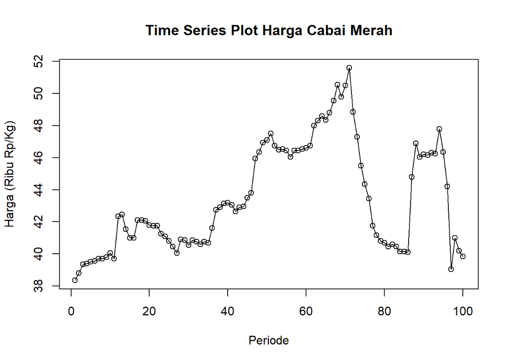

```r
ts.plot(cabai.ts, xlab = "Periode", ylab = "Harga (Ribu Rp/Kg)",
        main = "Time Series Plot Harga Cabai Merah")
points(cabai.ts)
```

Plot deret waktu menunjukkan data yang berfluktuasi naik-turun mengikuti siklus harga pasar, tanpa arah tren jangka panjang yang konsisten (harga naik pada suatu periode kemudian turun kembali pada periode berikutnya).

## Pembagian Data Latih dan Data Uji

Pembagian data dilakukan dengan perbandingan 80% data latih dan 20% data uji.

```r
n <- nrow(dataCabai)
n_train <- floor(0.8 * n)

training <- dataCabai[1:n_train, ]
testing  <- dataCabai[(n_train+1):n, ]

train.ts <- ts(training$Harga)
test.ts  <- ts(testing$Harga, start = n_train + 1)

n_train
```

```
## [1] 80
```

```r
n - n_train
```

```
## [1] 20
```

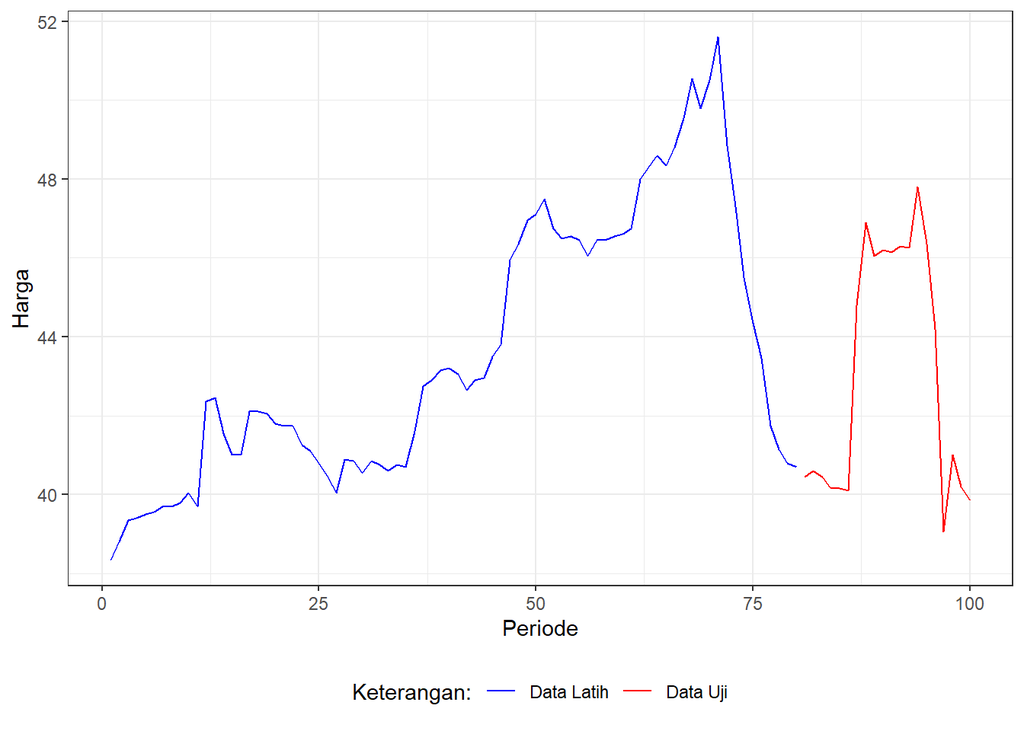

```r
ggplot() +
  geom_line(data = training, aes(x = Periode, y = Harga, col = "Data Latih")) +
  geom_line(data = testing, aes(x = Periode, y = Harga, col = "Data Uji")) +
  labs(x = "Periode", y = "Harga", color = "Legend") +
  scale_colour_manual(name = "Keterangan:", breaks = c("Data Latih", "Data Uji"),
                       values = c("blue", "red")) +
  theme_bw() + theme(legend.position = "bottom")
```

# Single Moving Average (SMA)

Metode SMA cocok digunakan untuk data dengan pola stasioner/konstan. Pemulusan dilakukan dengan `m = 4`.

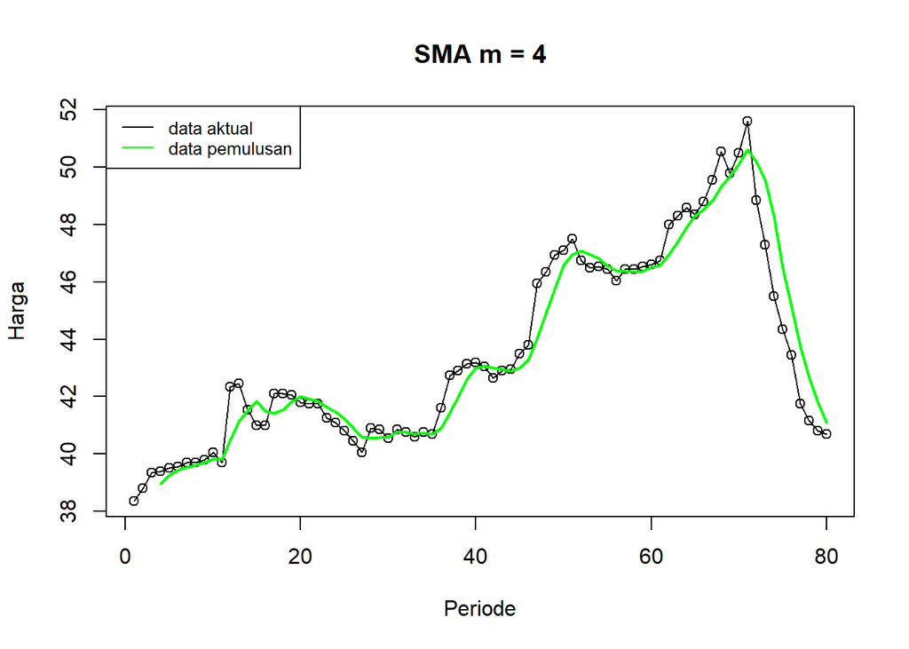

```r
m <- 4
data.sma <- SMA(train.ts, n = m)
ramalan.sma <- c(NA, data.sma)

#Plot hasil pemulusan pada data latih
ts.plot(train.ts, xlab = "Periode", ylab = "Harga", main = paste("SMA m =", m))
points(train.ts)
lines(data.sma, col = "green", lwd = 2)
legend("topleft", c("data aktual", "data pemulusan"), lty = 1, col = c("black","green"), cex = 0.8)
```

Nilai pemulusan pada periode terakhir data latih digunakan sebagai peramalan untuk seluruh periode data uji

```r
#Akurasi data latih
error_train.sma <- train.ts - ramalan.sma[1:length(train.ts)]
SSE_train.sma <- sum(error_train.sma[(m+1):length(train.ts)]^2)
MSE_train.sma <- mean(error_train.sma[(m+1):length(train.ts)]^2)
MAPE_train.sma <- mean(abs(error_train.sma[(m+1):length(train.ts)]/train.ts[(m+1):length(train.ts)])*100)

akurasi_train.sma <- matrix(c(SSE_train.sma, MSE_train.sma, MAPE_train.sma))
row.names(akurasi_train.sma) <- c("SSE", "MSE", "MAPE")
colnames(akurasi_train.sma) <- paste("SMA m =", m)
akurasi_train.sma
```

```
##       SMA m = 4
## SSE  134.327969
## MSE    1.767473
## MAPE   2.083222
```

```r
#Akurasi data uji (flat forecast dari nilai pemulusan terakhir)
ramalan_test.sma <- rep(tail(na.omit(data.sma), 1), length(test.ts))
error_test.sma <- test.ts - ramalan_test.sma

SSE_test.sma <- sum(error_test.sma^2)
MSE_test.sma <- mean(error_test.sma^2)
MAPE_test.sma <- mean(abs(error_test.sma/test.ts)*100)

akurasi_test.sma <- matrix(c(SSE_test.sma, MSE_test.sma, MAPE_test.sma))
row.names(akurasi_test.sma) <- c("SSE", "MSE", "MAPE")
colnames(akurasi_test.sma) <- paste("SMA m =", m)
akurasi_test.sma
```

```
##       SMA m = 4
## SSE  269.455000
## MSE   13.472750
## MAPE   6.531017
```

# Double Moving Average (DMA)

Metode DMA lebih sesuai untuk data berpola tren, karena melakukan pemulusan rata-rata sebanyak dua tahap sehingga mampu menangkap komponen level ($A_t$) dan tren ($B_t$).

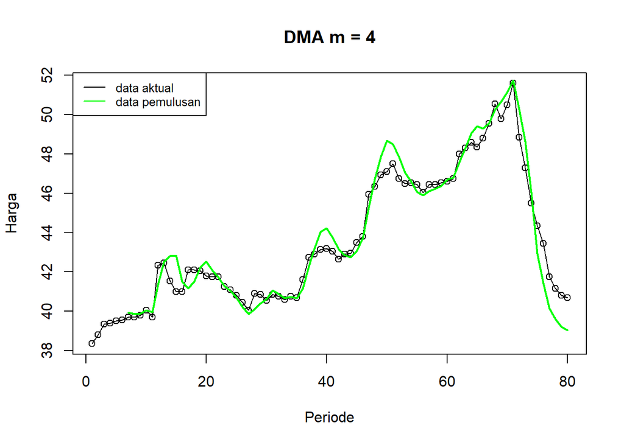

```r
dma <- SMA(data.sma, n = m)
At <- 2*data.sma - dma
Bt <- (2/(m-1))*(data.sma - dma)
data.dma <- At + Bt
ramalan.dma <- c(NA, data.dma)

ts.plot(train.ts, xlab = "Periode", ylab = "Harga", main = paste("DMA m =", m))
points(train.ts)
lines(data.dma, col = "green", lwd = 2)
legend("topleft", c("data aktual", "data pemulusan"), lty = 1, col = c("black","green"), cex = 0.8)
```

```r
#Akurasi data latih
skip <- 2*m - 1
error_train.dma <- train.ts - ramalan.dma[1:length(train.ts)]
SSE_train.dma <- sum(error_train.dma[(skip+1):length(train.ts)]^2)
MSE_train.dma <- mean(error_train.dma[(skip+1):length(train.ts)]^2)
MAPE_train.dma <- mean(abs(error_train.dma[(skip+1):length(train.ts)]/train.ts[(skip+1):length(train.ts)])*100)

akurasi_train.dma <- matrix(c(SSE_train.dma, MSE_train.dma, MAPE_train.dma))
row.names(akurasi_train.dma) <- c("SSE", "MSE", "MAPE")
colnames(akurasi_train.dma) <- paste("DMA m =", m)
akurasi_train.dma
```

```
##      DMA m = 4
## SSE  81.341747
## MSE   1.114271
## MAPE  1.762313
```

```r
#Peramalan data uji: ekstrapolasi linear At + Bt*h
h <- 1:length(test.ts)
At_akhir <- as.numeric(tail(na.omit(At), 1))
Bt_akhir <- as.numeric(tail(na.omit(Bt), 1))
ramalan_test.dma <- At_akhir + Bt_akhir*h

error_test.dma <- test.ts - ramalan_test.dma
SSE_test.dma <- sum(error_test.dma^2)
MSE_test.dma <- mean(error_test.dma^2)
MAPE_test.dma <- mean(abs(error_test.dma/test.ts)*100)

akurasi_test.dma <- matrix(c(SSE_test.dma, MSE_test.dma, MAPE_test.dma))
row.names(akurasi_test.dma) <- c("SSE", "MSE", "MAPE")
colnames(akurasi_test.dma) <- paste("DMA m =", m)
akurasi_test.dma
```

```
##       DMA m = 4
## SSE  3543.63946
## MSE   177.18197
## MAPE   27.11811
```

# Single Exponential Smoothing (SES)

SES memberi bobot yang menurun secara eksponensial pada data historis dan cocok untuk data tanpa tren maupun musiman yang jelas. Nilai parameter $\lambda$ (alpha) dioptimalkan agar SSE minimum.

```r
ses.opt <- ses(train.ts, h = length(test.ts), alpha = NULL)
ses.opt$model
```

```
## Simple exponential smoothing
##
## Call:
## ses(y = train.ts, h = length(test.ts), alpha = NULL)
##
##   Smoothing parameters:
##     alpha = 0.9999
##
##   Initial states:
##     l = 38.3493
##
##   sigma:  0.7638
##
##      AIC     AICc      BIC
## 311.4175 311.7333 318.5636
```

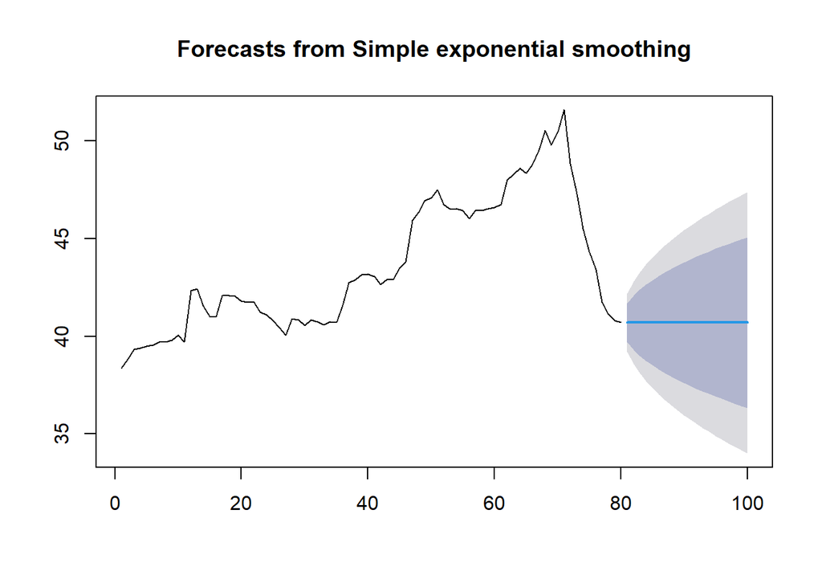

```r
plot(ses.opt)
```

```r
#Akurasi data latih
fit.ses <- fitted(ses.opt)
error_train.ses <- train.ts[-1] - fit.ses[-1]
SSE_train.ses <- sum(error_train.ses^2)
MSE_train.ses <- mean(error_train.ses^2)
MAPE_train.ses <- mean(abs(error_train.ses/train.ts[-1])*100)

akurasi_train.ses <- matrix(c(SSE_train.ses, MSE_train.ses, MAPE_train.ses))
row.names(akurasi_train.ses) <- c("SSE", "MSE", "MAPE")
colnames(akurasi_train.ses) <- "SES optimum"
akurasi_train.ses
```

```
##      SES optimum
## SSE   45.5002785
## MSE    0.5759529
## MAPE   1.1167117
```

```r
#Akurasi data uji
ramalan_test.ses <- ses.opt$mean
error_test.ses <- test.ts - ramalan_test.ses
SSE_test.ses <- sum(error_test.ses^2)
MSE_test.ses <- mean(error_test.ses^2)
MAPE_test.ses <- mean(abs(error_test.ses/test.ts)*100)

akurasi_test.ses <- matrix(c(SSE_test.ses, MSE_test.ses, MAPE_test.ses))
row.names(akurasi_test.ses) <- c("SSE", "MSE", "MAPE")
colnames(akurasi_test.ses) <- "SES optimum"
akurasi_test.ses
```

```
##      SES optimum
## SSE   305.454018
## MSE    15.272701
## MAPE    6.540625
```

Nilai $\alpha$ optimum yang dihasilkan mendekati 1, artinya bobot hampir seluruhnya diberikan pada data periode terakhir (mirip metode *naive*). Hal ini wajar terjadi pada data harga yang berfluktuasi mendekati pola *random walk*.

# Double Exponential Smoothing (DES)

DES (metode Holt) menambahkan komponen tren pada pemulusan eksponensial, menggunakan dua parameter yaitu $\alpha$ (level) dan $\beta$ (tren), yang juga dioptimalkan.

```r
des.opt <- HoltWinters(train.ts, gamma = FALSE)
des.opt
```

```
## Holt-Winters exponential smoothing with trend and without seasonal component.
##
## Call:
## HoltWinters(x = train.ts, gamma = FALSE)
##
## Smoothing parameters:
##  alpha: 1
##  beta : 0.2004481
##  gamma: FALSE
##
## Coefficients:
##         [,1]
## a 40.7000000
## b -0.6632576
```

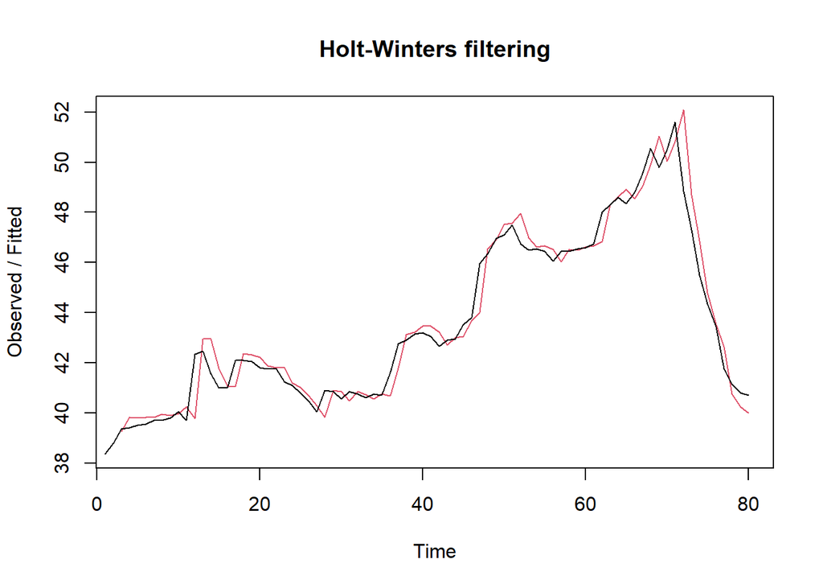

```r
plot(des.opt)
```

```r
ramalandes.opt <- forecast(des.opt, h = length(test.ts))
ramalandes.opt
```

```
##     Point Forecast    Lo 80    Hi 80     Lo 95    Hi 95
##  81       40.03674 39.08174 40.99174 38.576197 41.49729
##  82       39.37348 37.88140 40.86557 37.091536 41.65543
##  83       38.71023 36.70619 40.71427 35.645312 41.77514
##  84       38.04697 35.52608 40.56786 34.191601 41.90234
##  85       37.38371 34.33154 40.43588 32.715823 42.05160
##  86       36.72045 33.11879 40.32212 31.212179 42.22873
##  87       36.05720 31.88623 40.22817 29.678247 42.43615
##  88       35.39394 30.63327 40.15461 28.113119 42.67476
##  89       34.73068 29.35981 40.10156 26.516636 42.94473
##  90       34.06742 28.06599 40.06886 24.889026 43.24582
##  91       33.40417 26.75210 40.05623 23.230713 43.57762
##  92       32.74091 25.41849 40.06333 21.542230 43.93959
##  93       32.07765 24.06552 40.08978 19.824154 44.33115
##  94       31.41439 22.69359 40.13519 18.077079 44.75171
##  95       30.75114 21.30309 40.19918 16.301600 45.20067
##  96       30.08788 19.89440 40.28136 14.498299 45.67746
##  97       29.42462 18.46788 40.38136 12.667738 46.18150
##  98       28.76136 17.02390 40.49883 10.810460 46.71226
##  99       28.09810 15.56279 40.63342  8.926988 47.26922
## 100       27.43485 14.08487 40.78482  7.017819 47.85188
```

```r
#Akurasi data latih
ssedes.train <- des.opt$SSE
msedes.train <- ssedes.train/length(train.ts)
sisaandes <- ramalandes.opt$residuals
mapedes.train <- mean(abs(sisaandes[3:length(train.ts)]/train.ts[3:length(train.ts)])*100, na.rm = TRUE)

akurasides.opt <- matrix(c(ssedes.train, msedes.train, mapedes.train))
row.names(akurasides.opt) <- c("SSE", "MSE", "MAPE")
colnames(akurasides.opt) <- "DES optimum"
akurasides.opt
```

```
##      DES optimum
## SSE   43.1541938
## MSE    0.5394274
## MAPE   1.0966053
```

```r
#Akurasi data uji
selisihdes.opt <- ramalandes.opt$mean - test.ts
SSEtestingdes.opt <- sum(selisihdes.opt^2)
MSEtestingdes.opt <- SSEtestingdes.opt/length(test.ts)
MAPEtestingdes.opt <- mean(abs(selisihdes.opt/test.ts)*100)

akurasiDesTesting <- matrix(c(SSEtestingdes.opt, MSEtestingdes.opt, MAPEtestingdes.opt))
row.names(akurasiDesTesting) <- c("SSE", "MSE", "MAPE")
colnames(akurasiDesTesting) <- "DES optimum"
akurasiDesTesting
```

```
##      DES optimum
## SSE   2313.50027
## MSE    115.67501
## MAPE    21.34778
```

Sama seperti DMA, DES juga mengasumsikan adanya tren pada data. Karena tren pada data harga cabai tidak konsisten (naik lalu turun tajam), hasil ramalan DES pada data uji memiliki *error* yang jauh lebih besar dibandingkan SMA maupun SES.

# Perbandingan Kinerja Metode

## Perbandingan pada Data Latih

```r
akurasi.train.full <- cbind(akurasi_train.sma, akurasi_train.dma,
                             akurasi_train.ses, akurasides.opt)
colnames(akurasi.train.full) <- c("SMA", "DMA", "SES", "DES")
akurasi.train.full
```

```
##             SMA       DMA        SES        DES
## SSE  134.327969 81.341747 45.5002785 43.1541938
## MSE    1.767473  1.114271  0.5759529  0.5394274
## MAPE   2.083222  1.762313  1.1167117  1.0966053
```

## Perbandingan pada Data Uji

```r
akurasi.test.full <- cbind(akurasi_test.sma, akurasi_test.dma,
                            akurasi_test.ses, akurasiDesTesting)
colnames(akurasi.test.full) <- c("SMA", "DMA", "SES", "DES")
akurasi.test.full
```

```
##             SMA        DMA        SES        DES
## SSE  269.455000 3543.63946 305.454018 2313.50027
## MSE   13.472750  177.18197  15.272701  115.67501
## MAPE   6.531017   27.11811   6.540625   21.34778
```

# Kesimpulan

Pada **data latih**, metode DES memiliki SSE/MSE/MAPE terkecil, diikuti oleh SES, DMA, kemudian SMA. Hal ini wajar karena metode yang lebih fleksibel (memiliki komponen tren dan/atau bobot yang dioptimalkan) cenderung memiliki kecocokan (*fit*) terbaik terhadap data yang sama-sama digunakan untuk melatih parameternya.

Namun demikian, **kinerja pada data uji** justru menunjukkan hal sebaliknya: metode **SMA** dan **SES** memiliki MAPE yang jauh lebih kecil (sekitar 6.5%) dibandingkan metode **DMA** dan **DES** (masing-masing sekitar 21-27%). Hal ini terjadi karena data harga cabai merah tidak memiliki arah tren jangka panjang yang konsisten, melainkan berfluktuasi naik-turun mengikuti dinamika pasar. Metode DMA dan DES yang mengasumsikan adanya komponen tren melakukan ekstrapolasi tren dari akhir data latih, sehingga ketika arah pergerakan harga pada data uji berbalik arah, ramalan kedua metode tersebut menyimpang jauh dari nilai aktual (*overfitting terhadap tren lokal*). Sebaliknya, SMA dan SES tidak mengekstrapolasi tren sehingga lebih tahan terhadap perubahan arah pergerakan harga secara tiba-tiba.

Berdasarkan kinerja pada data uji – yang merepresentasikan kemampuan generalisasi/peramalan metode terhadap data baru – maka metode **Single Moving Average (SMA)** dan **Single Exponential Smoothing (SES)** dipilih sebagai metode pemulusan terbaik untuk data harga cabai merah ini, dengan **SMA** sedikit unggul pada seluruh ukuran akurasi (SSE, MSE, dan MAPE) dibandingkan SES. Metode DMA dan DES kurang tepat digunakan pada data ini karena data tidak menunjukkan pola tren yang stabil.